# Geoprocessing 1 - Geometric Measurements

In this Notebook we will use functions from `sf` that measure geometric properties (area, length, distance).

- compute the total area of YNP in meters<sup>2</sup> and miles<sup>2</sup>
- compute the area of watersheds
- compute the total length of roads
- compute the distance between campgrounds and cell towers

## Setup

Load the packages we’ll need and set tmap mode to ‘plot’:

```r
library(sf)
library(units)
library(tmap)
tmap_mode("plot")
```

```
tmap mode set to plotting
```

Load `dplyr` and set name conflict preferences:

```r
library(dplyr)

## Load the conflicted package
library(conflicted)

# Set conflict preferences
conflict_prefer("filter", "dplyr", quiet = TRUE)
conflict_prefer("count", "dplyr", quiet = TRUE)
conflict_prefer("select", "dplyr", quiet = TRUE)
conflict_prefer("arrange", "dplyr", quiet = TRUE)
```

## Import the Park Boundary

```r
## Define a convenience variable for UTM Zone 11
epsg_utm11n_nad83 <- 26911

## Import the YNP border
yose_bnd_utm <- st_read(dsn="./data", layer="yose_boundary") %>%
  st_transform(epsg_utm11n_nad83)
```

## Compute the area of the park

Find area with `st_area()`:

```r
yose_area <- yose_bnd_utm %>% st_area()
yose_area
```

```
3019918537 [m^2]
```

Find the area in miles<sup>2</sup>.

```r
## View in square miles
set_units(yose_area, mi^2)
```

```
1165.997 [mi^2]
```

## Import the Watersheds

Next import the watershed boundaries.

```r
yose_watersheds_utm <- st_read("./data/yose_watersheds.gpkg", layer="calw221") %>%
  st_transform(epsg_utm11n_nad83) %>%
  select(CALWNUM, HRNAME, RBNAME, HUNAME, CDFSPWNAME, CDFPWSNAME, HUC_8, HUC_8_NAME)
yose_watersheds_utm %>% slice(1:10) %>% as_tibble()
```

| CALWNUM | HRNAME | RBNAME | HUNAME | CDFSPWNAME | CDFPWSNAME | HUC_8 | HUC_8_NAME | geom |
| --- | --- | --- | --- | --- | --- | --- | --- | --- |
| 8631.400101 | North Lahontan | Lahontan | WEST WALKER RIVER | Headwaters West Walker River | Cascade Creek | 16050302 | WEST_WALKER-CA,NV |  |
| 8630.400204 | North Lahontan | Lahontan | EAST WALKER RIVER | Buckeye Creek | Upper Buckeye Creek | 16050301 | EAST_WALKER-CA,NV |  |
| 8631.400104 | North Lahontan | Lahontan | WEST WALKER RIVER | Headwaters West Walker River | Kirkwood Creek | 16050302 | WEST_WALKER-CA,NV |  |
| 6536.510101 | San Joaquin | Central Valley | TUOLUMNE RIVER | Huckleberry Lake | East Fork Cherry Creek | 18040009 | UPPER_TUOLUMNE |  |
| 6536.600801 | San Joaquin | Central Valley | TUOLUMNE RIVER | Falls Creek | Upper Jack Main Canyon | 18040009 | UPPER_TUOLUMNE |  |
| 8630.400301 | North Lahontan | Lahontan | EAST WALKER RIVER | Twin Lakes | Horse Creek | 16050301 | EAST_WALKER-CA,NV |  |
| 8630.400302 | North Lahontan | Lahontan | EAST WALKER RIVER | Twin Lakes | Cattle Creek | 16050301 | EAST_WALKER-CA,NV |  |
| 8630.400400 | North Lahontan | Lahontan | EAST WALKER RIVER | Green Creek | undefined | 16050301 | EAST_WALKER-CA,NV |  |
| 8630.400306 | North Lahontan | Lahontan | EAST WALKER RIVER | Twin Lakes | Little Slide Canyon | 16050301 | EAST_WALKER-CA,NV |  |
| 6536.600701 | San Joaquin | Central Valley | TUOLUMNE RIVER | Rancheria Creek | Thompson Canyon | 18040009 | UPPER_TUOLUMNE |  |

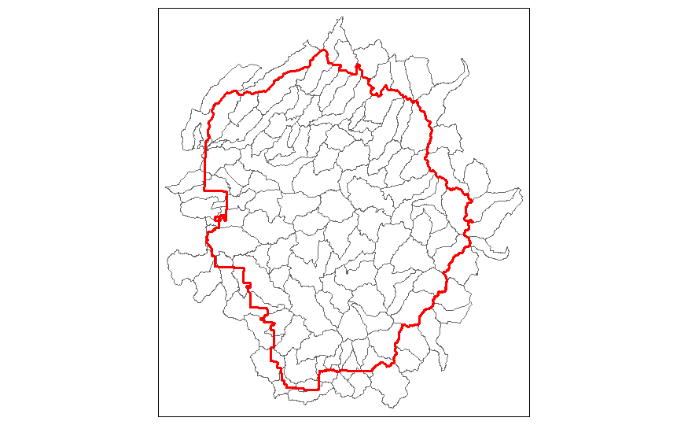

```r
tm_shape(yose_watersheds_utm) +
  tm_borders() +
tm_shape(yose_bnd_utm) +
  tm_borders(col="red", lwd=3)
```

## CHALLENGE: Compute the watershed areas

Compute the watershed areas, and add them as a new column in the attribute table. [Answer](https://bit.ly/3dov9Zw)

```r
## Compute the area in map units
yose_watersheds_areas_m2 <- st_area(yose_watersheds_utm)

## Add the area to the attribute table
yose_watersheds_utm <- yose_watersheds_utm %>%
  mutate(area_m2 = yose_watersheds_areas_m2)

## Preview results
yose_watersheds_utm %>% slice(1:10) %>% as_tibble()
```

| CALWNUM | HRNAME | RBNAME | HUNAME | CDFSPWNAME | CDFPWSNAME | HUC_8 | HUC_8_NAME | area_m2 | geom |
| --- | --- | --- | --- | --- | --- | --- | --- | --- | --- |
| 8631.400101 | North Lahontan | Lahontan | WEST WALKER RIVER | Headwaters West Walker River | Cascade Creek | 16050302 | WEST_WALKER-CA,NV | 24628591 [m^2] |  |
| 8630.400204 | North Lahontan | Lahontan | EAST WALKER RIVER | Buckeye Creek | Upper Buckeye Creek | 16050301 | EAST_WALKER-CA,NV | 40041051 [m^2] |  |
| 8631.400104 | North Lahontan | Lahontan | WEST WALKER RIVER | Headwaters West Walker River | Kirkwood Creek | 16050302 | WEST_WALKER-CA,NV | 27411634 [m^2] |  |
| 6536.510101 | San Joaquin | Central Valley | TUOLUMNE RIVER | Huckleberry Lake | East Fork Cherry Creek | 18040009 | UPPER_TUOLUMNE | 51189774 [m^2] |  |
| 6536.600801 | San Joaquin | Central Valley | TUOLUMNE RIVER | Falls Creek | Upper Jack Main Canyon | 18040009 | UPPER_TUOLUMNE | 35788003 [m^2] |  |
| 8630.400301 | North Lahontan | Lahontan | EAST WALKER RIVER | Twin Lakes | Horse Creek | 16050301 | EAST_WALKER-CA,NV | 31163634 [m^2] |  |
| 8630.400302 | North Lahontan | Lahontan | EAST WALKER RIVER | Twin Lakes | Cattle Creek | 16050301 | EAST_WALKER-CA,NV | 43630944 [m^2] |  |
| 8630.400400 | North Lahontan | Lahontan | EAST WALKER RIVER | Green Creek | undefined | 16050301 | EAST_WALKER-CA,NV | 50434074 [m^2] |  |
| 8630.400306 | North Lahontan | Lahontan | EAST WALKER RIVER | Twin Lakes | Little Slide Canyon | 16050301 | EAST_WALKER-CA,NV | 24693580 [m^2] |  |
| 6536.600701 | San Joaquin | Central Valley | TUOLUMNE RIVER | Rancheria Creek | Thompson Canyon | 18040009 | UPPER_TUOLUMNE | 36876506 [m^2] |  |

## CHALLENGE: Find the largest watershed

Find the largest watershed, and report the area in acres. [Answer](https://bit.ly/3uaY4HE)

```r
## Find the biggest watershed
yose_watersheds_utm %>%
  st_drop_geometry() %>%     ## get rid of the geometry column - don't need it
  top_n(1, area_m2)
```

| CALWNUM | HRNAME | RBNAME | HUNAME | CDFSPWNAME | CDFPWSNAME | HUC_8 | HUC_8_NAME | area_m2 |
| --- | --- | --- | --- | --- | --- | --- | --- | --- |
| 6537.500304 | San Joaquin | Central Valley | MERCED RIVER | McCauley | Crane Creek | 18040008 | UPPER_MERCED | 81006745 [m^2] |

```r
## Compute the area in acres
yose_watersheds_utm %>%
  st_drop_geometry() %>%     ## get rid of the geometry column - don't need it
  top_n(1, area_m2) %>%
  pull(area_m2) %>%
  set_units("acres")
```

```
20017.12 [acres]
```

## Import the Roads

```r
yose_roads_utm <- st_read("./data/yose_roads.gdb", "Yosemite_Roads") %>%
  st_transform(epsg_utm11n_nad83) %>%
  select(RDNAME, RTENUMBER, YOSE_Surface, YOSE_FIRE_ROAD, YOSE_INPARK, YOSE_Type)
```

Compute the length of roads and save it in the attribute table:

```r
yose_roads_utm <- yose_roads_utm %>%
  mutate(rd_length = st_length(yose_roads_utm))
yose_roads_utm %>% slice(1:10) %>% as_tibble()
```

| RDNAME | RTENUMBER | YOSE_Surface | YOSE_FIRE_ROAD | YOSE_INPARK | YOSE_Type | rd_length | Shape |
| --- | --- | --- | --- | --- | --- | --- | --- |
| Northside Drive | NA | Paved | No | Yes | Primary Road | 493.53512 [m] |  |
| Northside Drive | NA | Paved | No | Yes | Primary Road | 67.90781 [m] |  |
| Northside Drive | NA | Paved | No | Yes | Primary Road | 33.35863 [m] |  |
| Southside Drive | NA | Paved | No | Yes | Primary Road | 258.00073 [m] |  |
| Northside Drive | NA | Paved | No | Yes | Primary Road | 117.94169 [m] |  |
| Northside Drive | NA | Paved | No | Yes | Primary Road | 167.51558 [m] |  |
| Mirror Lake road | NA | Paved | No | Yes | Secondary Road | 71.82903 [m] |  |
| Happy Isles Loop | NA | Paved | No | Yes | Primary Road | 330.03084 [m] |  |
| Mirror Lake road | NA | Paved | No | Yes | Secondary Road | 73.37367 [m] |  |
| Happy Isles Loop | NA | Paved | No | Yes | Primary Road | 80.21527 [m] |  |

## CHALLENGE: Compute Road Lengths

Find the total length for each type of Road (see YOSE_Type) in miles. [Answer](https://bit.ly/3wbbLbb)

```r
yose_roads_utm %>%
  st_drop_geometry() %>%
  group_by(YOSE_Type) %>%
  summarise(length_miles = sum(rd_length) %>% set_units("mi")) %>%
  arrange(desc(length_miles))
```

| YOSE_Type | length_miles |
| --- | --- |
| Primary Road | 291.741718 [mi] |
| Secondary Road | 175.979652 [mi] |
| Dirt Road | 103.734244 [mi] |
| Tertiary Road (Residential) | 42.502989 [mi] |
| Campground Road | 31.066399 [mi] |
| NPS Service Road | 14.100675 [mi] |
| Parking Lot or Pullout | 6.109527 [mi] |
| Gravel Road | 3.176868 [mi] |
| Tunnel | 1.645088 [mi] |

## Import the Campgrounds and Cell Towers

```r
yose_campgrounds_utm <- st_read("./data", layer="yose_poi") %>%
  st_transform(epsg_utm11n_nad83) %>%
  filter(POITYPE == 'Campground') %>%
  select(POINAME)
yose_celltwrs_utm <- st_read("./data/yose_communications.gdb", "Cell_Towers") %>%
  st_transform(epsg_utm11n_nad83)
```

Plot them:

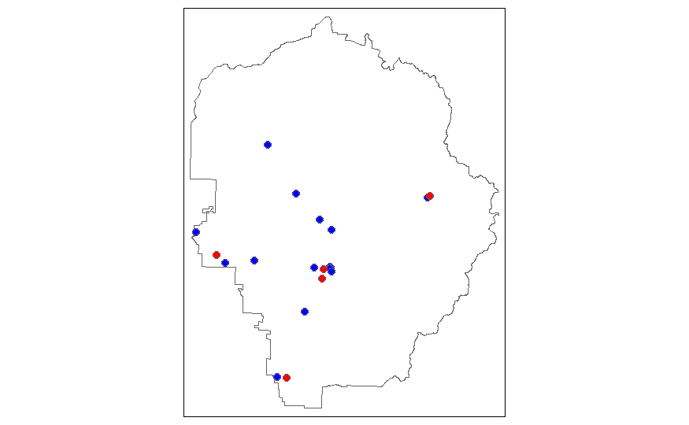

```r
tm_shape(yose_bnd_utm) +
  tm_borders() +
tm_shape(yose_campgrounds_utm) +
  tm_symbols(size = 0.3, col = "blue") +
tm_shape(yose_celltwrs_utm) +
  tm_symbols(size = 0.3, col = "red")
```

## Compute Distances Between Features - 1 sf data frame

`st_distance()` can be used to compute distances between features. If you pass it one sf object, it will return a symmetric distance matrix between all pairs of features.

Compute the distance between all pairs of campgrounds:

```r
campgrounds_dist_mat <- st_distance(yose_campgrounds_utm)
campgrounds_dist_mat
```

```
Units: [m]
           1         2         3         4         5         6        7         8        9        10         11
1      0.000  8275.796 12628.738 20897.961 24202.415 26366.307 45699.01 26318.172 32505.98 24022.360 27053.5366
2   8275.796     0.000  5634.176 19310.626 20243.499 21669.864 41526.22 18231.678 24574.95 17323.278 20522.7859
3  12628.738  5634.176     0.000 15448.311 15106.794 16243.769 36084.79 14050.939 23230.46 11754.726 14931.6215
4  20897.961 19310.626 15448.311     0.000  6776.104  9775.471 25681.09 23140.503 36074.82 14860.874 15706.6234
5  24202.415 20243.499 15106.794  6776.104     0.000  3014.800 21555.06 18297.281 31962.27  9501.164  9443.6883
6  26366.307 21669.864 16243.769  9775.471  3014.800     0.000 19858.20 16911.114 30774.47  8198.298  7236.6861
7  45699.014 41526.218 36084.793 25681.086 21555.058 19858.200     0.00 32839.145 45873.18 26134.546 23327.6854
8  26318.172 18231.678 14050.939 23140.503 18297.281 16911.114 32839.14     0.000 13892.94  8814.694 10183.5588
9  32505.983 24574.955 23230.456 36074.816 31962.268 30774.468 45873.18 13892.936     0.00 22606.591 24037.3432
10 24022.360 17323.278 11754.726 14860.874  9501.164  8198.298 26134.55  8814.694 22606.59     0.000  3222.2366
11 27053.537 20522.786 14931.621 15706.623  9443.688  7236.686 23327.69 10183.559 24037.34  3222.237     0.0000
12 27174.786 20589.170 15009.085 15972.557  9717.027  7503.431 23439.68  9979.152 23820.38  3268.848   273.4135
13 27088.787 20464.194 14892.172 16067.174  9849.639  7671.851 23645.40  9768.727 23613.03  3140.976   440.3027
```

[output cut: 18 more lines]

## Compute Distances Between Features - 2 sf data frames

If you pass two sf objects to `st_distance()`, it will return a *n x m* matrix containing the distance between all pairs of features.

Compute the distance between all pairs of campgrounds and cell towers:

```r
cgct_dist_mat <- st_distance(yose_campgrounds_utm, yose_celltwrs_utm)
cgct_dist_mat
```

```
Units: [m]
            [,1]      [,2]      [,3]      [,4]      [,5]
 [1,] 46219.4109 25884.856 26225.834 33538.244  5903.577
 [2,] 42063.8195 19210.673 19163.004 25491.865  2384.789
 [3,] 36624.3349 13645.182 13737.613 23773.991  7499.216
 [4,] 26168.3039 15613.133 17308.435 36061.840 19627.095
 [5,] 22082.7907  9689.048 11543.363 31666.279 21313.320
 [6,] 20396.4206  7834.371  9723.708 30321.762 22987.367
 [7,]   541.1383 24682.675 25995.385 44830.662 42783.486
 [8,] 33352.8435  9178.442  7376.002 13416.944 20585.520
 [9,] 46361.8785 23070.914 21252.438  1824.674 26769.154
[10,] 26671.4314  1890.457  2646.959 22220.557 19249.627
[11,] 23859.2190  1411.166  2821.810 23427.597 22413.196
[12,] 23970.1116  1403.475  2639.230 23199.118 22497.225
[13,] 24175.5888  1257.224  2426.427 22995.829 22383.935
[14,] 24211.1160  1733.602  2314.224 22611.632 22843.581
[15,] 33272.4448 26622.758 28245.217 45778.512 23754.044
```

## CHALLENGE: Find the closest cell tower

For the first campground (row), which is the closest cell tower? [Answer](https://bit.ly/3webTXp)

Hint: use `which.min()`

```r
which.min(cgct_dist_mat[1,])
```

```
[1] 5
```

```r
## Or for all campgrounds:
apply(cgct_dist_mat, 1, which.min)
```

```
 [1] 5 5 5 2 2 2 1 3 4 2 2 2 2 2 5
```

## End

Congratulations, you’ve completed the Notebook!

To view your Notebook at HTML, save it (again), then click the ‘Preview’ button in the RStudio toolbar.